# Part 2

FINAL IDEA (#2 from Part 1): This database is at almost every university and library. It can be for students or any customer of a library to see if the book they need is in stock or not. It also helps people navigate through finding the books. Once someone checks out a book, the database updates and changes the quantity of the books available. This function works similarly if a student or employee is dropping off a book. Specific entities keep tables in the dataset that includes details like book I.D, Book Title, availability, quantity, and genre. It also keeps details like the persons name, account number, number of books checked out, number of overdue books, and address. Based on the data in the table, the system will either allow for the book to be checked out or not. If the account has record that there are any books overdue, nothing can be checked out. You will be able to see which books are most popular by seeing the "availability" and the "quantity" columns. From this, you can see the correlation between the amount of copies brought in and how many of them have been checked out since. Also, if it were to be an app, an 'indoor map' of the building can be put in and updates as sections change from the data of the table. This way, for people who don't know how to navigate themselves through a library can use this to find their book quick. Another feature that could be added is as people put themselves on hold for the book to come back, the database automatically changes to checked-out so their place in line can be held. The relationships are that the customer issues and returns the books. Once a book has been checked out for 4 months longer than it's due date, the book will be reported missing in the database under the customers account and thus will generate a bill to said customer. Also, customers can use this on the computers at the library. Employees are another example of entities. This table shows you their name, id, activity status, previous transactions, and their hours. The activity status tells other employees are clocked in or not and the hours column tells what time(s) they will be there on a given day. Under the 'previous transaction' column, employees can see the most recent item they issued or returned, if any conflict were to arise. The actual database would keep all the data for a certain amount of time so that employees can address any further issues. Another entity could be a 'branch 'section. This will log managers at each branch. In the 'books' section, there is a column where you can see the availability at other locations, this way when a customer wants a book that is out of stock, an employee can check to see if it is available anywhere else. Under "branch" you can also see if any location is low in stock,this way other locations can supply. End-user data would be the books that the customers looked up and/or checked out. This would be determined using the user table by which surverys would be conducted and information would be inputted into the database. Previous tables were explained as well as their relationships. Some of the new relationships that could be described are book -> user is 1:1, user -> branch is 1:1, employee -> branch is 1:1, and bill to user is 1:1. Finally, some constraints that can be described are weekly hours can be between 0-60, customer bill is typically $1-$500, as well as others.

[figure not shown]

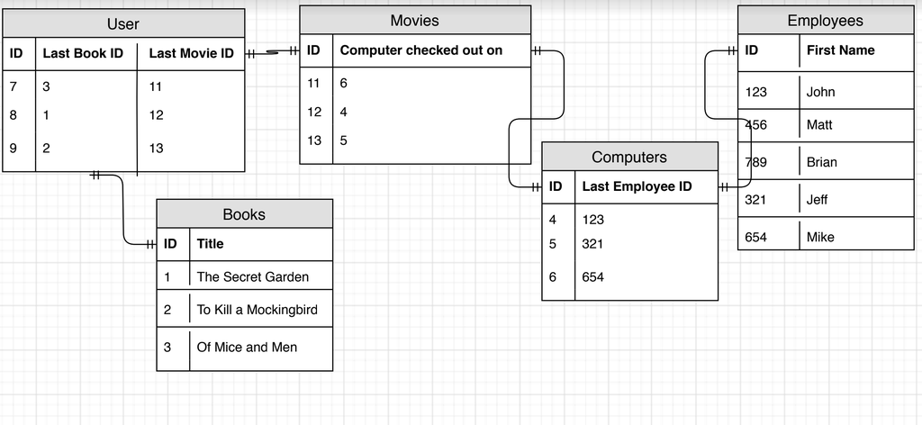

[figure not shown]